# Untitled

Mitch Holman, Tucker Southern, Matt McCaskey

11/14/2017

1. Download the data stored in AsULearn under the filename ElectricityPrice.csv. Attach and describe the time series plot of the electricity price data.

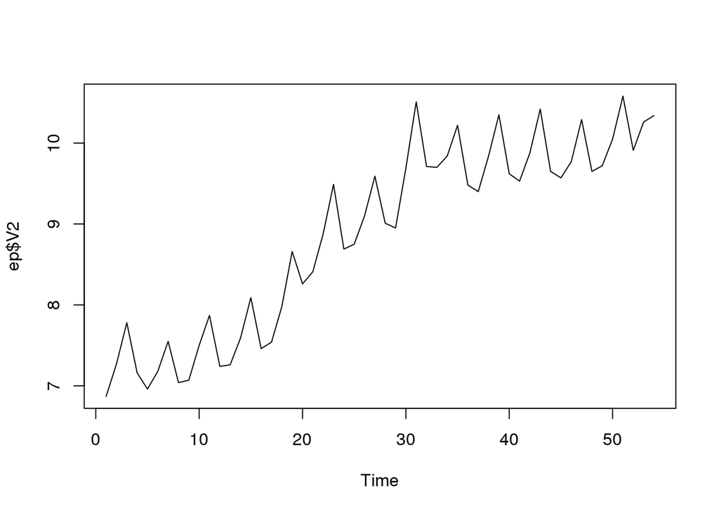

```r
ep <- read.csv("/home/students/holmanma/TS/Time_S/ts/ElectricityPrice.csv", header = F)
plot.ts(ep$V2)
```

The price begins by oscillating between 7 and 8 and increases till it is oscillating between 9 and 10.

2. Remove the overall increasing trend in this data using an appropriate de-trending method. Attach and describe the time series plot of de-trended data.

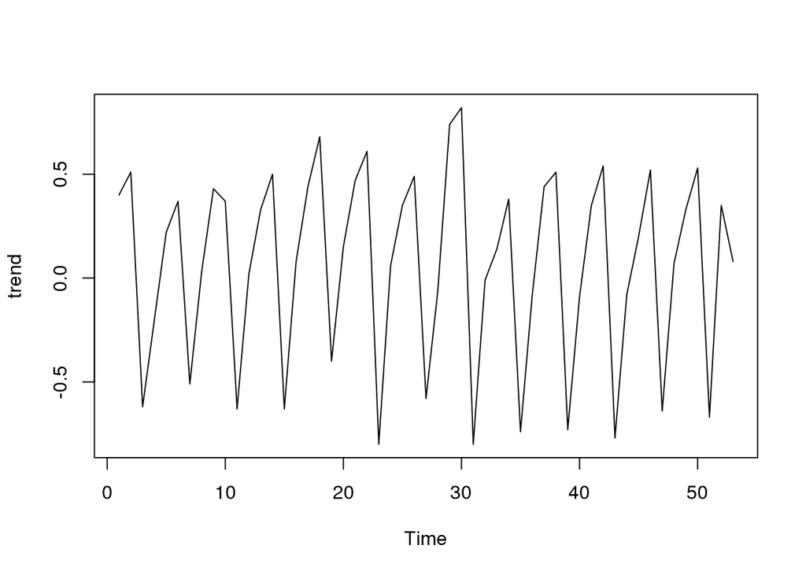

```r
trend <- diff(ep$V2, lag = 1)
plot.ts(trend)
```

The increasing trend of the original data has been removed so that all of the data lies between -1 and 1

3. Using a seasonal regression model with dummy variables, obtain the seasonally-adjusted de-trended electricity price data. Attach and describe the time series plot of this data.

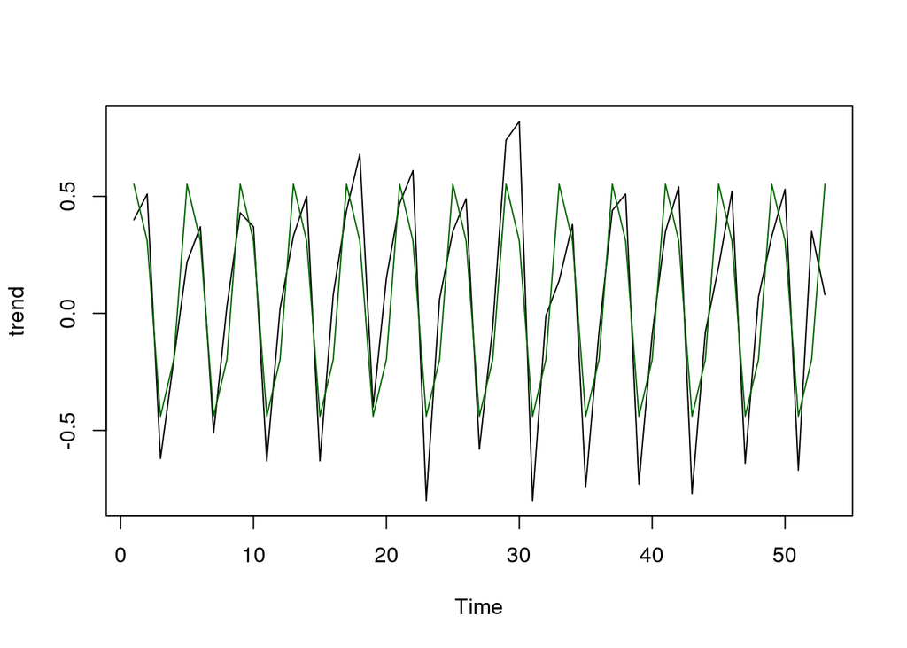

```r
t <- 1:53
X1 <- sin(2*pi*t/4)
X2 <- cos(2*pi*t/4)
trig <- lm(trend ~ X1 + X2)
plot.ts(trend)
lines(trig$fitted.values, col = "dark green")
```

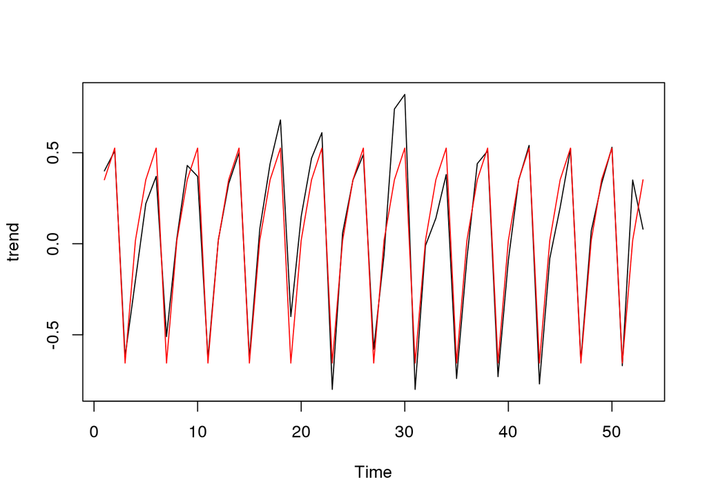

```r
Q2 <- rep(c(1,0,0,0),13)      #I changed this because the Differenced data starts with a value for Q2 -MJM
Q2[53] <- 1
Q3 <- rep(c(0,1,0,0),13)
Q3[53] <- 0
Q4 <- rep(c(0,0,1,0),13)
Q4[53] <- 0
dummy <- lm(trend ~ Q2 + Q3 + Q4)
plot.ts(trend)
lines(dummy$fitted.values, col = "red")
```

4. Obtain the best ARIMA model you can fit for the data in #3. Explain how you arrived at your final model.

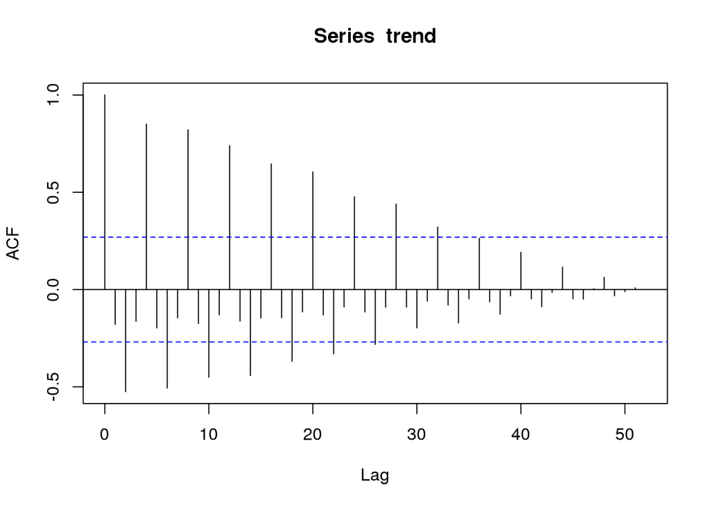

```r
acf(trend,53)
```

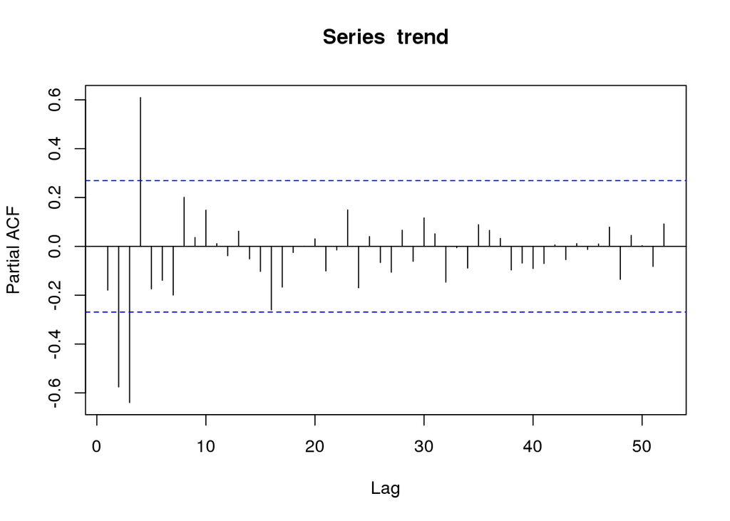

```r
pacf(trend,53)
```

```r
arima(trend, order = c(1,0,0))
```

```
##
## Call:
## arima(x = trend, order = c(1, 0, 0))
##
## Coefficients:
##           ar1  intercept
##       -0.1776     0.0645
## s.e.   0.1345     0.0538
##
## sigma^2 estimated as 0.2118:  log likelihood = -34.09,  aic = 74.18
```

```r
arima(trend, order = c(2,0,0))
```

```
##
## Call:
## arima(x = trend, order = c(2, 0, 0))
##
## Coefficients:
##           ar1      ar2  intercept
##       -0.2929  -0.5817     0.0579
## s.e.   0.1113   0.1092     0.0276
##
## sigma^2 estimated as 0.1378:  log likelihood = -23.12,  aic = 54.23
```

```r
arima(trend, order = c(0,0,1))
```

```
##
## Call:
## arima(x = trend, order = c(0, 0, 1))
##
## Coefficients:
##           ma1  intercept
##       -0.6845     0.0614
## s.e.   0.0885     0.0183
##
## sigma^2 estimated as 0.1639:  log likelihood = -27.59,  aic = 61.18
```

```r
arima(trend, order = c(0,0,2))
```

```
##
## Call:
## arima(x = trend, order = c(0, 0, 2))
##
## Coefficients:
##           ma1      ma2  intercept
##       -0.4300  -0.2688     0.0626
## s.e.   0.1227   0.1101     0.0174
##
## sigma^2 estimated as 0.154:  log likelihood = -25.91,  aic = 59.83
```

```r
arima(trend, order = c(1,0,1))
```

```
##
## Call:
## arima(x = trend, order = c(1, 0, 1))
##
## Coefficients:
##          ar1      ma1  intercept
##       0.1638  -0.7442     0.0622
## s.e.  0.1775   0.1047     0.0179
##
## sigma^2 estimated as 0.1613:  log likelihood = -27.14,  aic = 62.28
```

```r
arima(trend, order = c(1,0,2))
```

```
##
## Call:
## arima(x = trend, order = c(1, 0, 2))
##
## Coefficients:
##           ar1      ma1      ma2  intercept
##       -0.1246  -0.3410  -0.3131     0.0622
## s.e.   0.2499   0.2092   0.1317     0.0176
##
## sigma^2 estimated as 0.1532:  log likelihood = -25.79,  aic = 61.57
```

```r
arima(trend, order = c(2,0,1))
```

```
##
## Call:
## arima(x = trend, order = c(2, 0, 1))
##
## Coefficients:
##           ar1      ar2      ma1  intercept
##       -0.0799  -0.5888  -0.4020     0.0590
## s.e.   0.1311   0.1113   0.1216     0.0172
##
## sigma^2 estimated as 0.1153:  log likelihood = -18.59,  aic = 47.18
```

```r
arima(trend, order = c(2,0,2))
```

```
##
## Call:
## arima(x = trend, order = c(2, 0, 2))
##
## Coefficients:
##          ar1      ar2      ma1     ma2  intercept
##       0.0123  -0.9549  -0.4498  1.0000     0.0603
## s.e.  0.0353   0.0301   0.0704  0.0779     0.0256
##
## sigma^2 estimated as 0.05461:  log likelihood = -2.21,  aic = 16.43
```

```r
mod <- arima(trend, order = c(2,0,2))
mod
```

```
##
## Call:
## arima(x = trend, order = c(2, 0, 2))
##
## Coefficients:
##          ar1      ar2      ma1     ma2  intercept
##       0.0123  -0.9549  -0.4498  1.0000     0.0603
## s.e.  0.0353   0.0301   0.0704  0.0779     0.0256
##
## sigma^2 estimated as 0.05461:  log likelihood = -2.21,  aic = 16.43
```

The best ARIMA model we fit was arima(trend,order= c(2,0,2)). We observed the aic from this model and it was the closest to zero.

5. What is the forecast of the electricity price for the 3rd quarter of 2014?

```r
arimapred <- predict(mod, n.ahead=1)
arimapred$pred[1] + ep$V2[54]
```

```
## [1] 10.62817
```

Upload the completed .html file at the Activity 8 Submission folder in AsULearn by midnight on Tuesday, Nov. 21, 2017.